# Resultados de la evaluación censal de estudiantes de segundo grado de primaria

04 Mayo, 2023

[figure not shown]

# 1 **Introducción**

## 1.1 **Diagrama de Gantt**

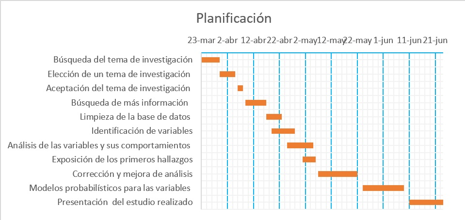

## 1.2 **Relevancia :**

La relevancia de este estudio es alta ya que con los resultados que se obtienen en los censos se podrá saber como va evolucionando el sector educativo. En nuestro país a diferencia de otros países del mundo se sabe que la calidad educativa no es muy alta por lo que es de suma importancia realizar estos estudios a los alumnos para saber como se están desarrollando académicamente.

## 1.3 **Factibilidad:**

En este estudio nos enfocaremos en los estudiantes de segundo grado de primaria,de acuerdo a como van los resultados que se obtuvieron en el censo del año 2015 y 2016 se podrá tener una visión más clara de como van los estudiantes en cada distritos.

## 1.4 **Objetivo:**

Objetivo: Mostrar que regiones del Perú obtuvieron un bajo rendimiento académico en el Censo Estudiantil que se dio en el 2016 y a la vez compararlas con los resultados del 2015

# 2 **Datos**

## 2.1 **Recopilación de datos:**

Esta base de datos fue recopilada por el Ministerio de educación en el año 2015 y 2016, y posteriormente publicado en el año 2018.Para la recolección de datos se tomó un examen el cual media los conocimientos de matemáticas y lectura, de los estudiantes de segundo grado de primaria,cuarto grado de primaria y segundo grado de secundaria, Este examen fue tomado en algunas fechas específicas en casi todos los colegios del Perú durante el horario en el que se dictaban las clases, esto para poder llegar a casi la totalidad de estudiantes. Las notas van desde 0 a 1000, y se agrupaba a los estudiantes de la siguiente forma según sus resultados.

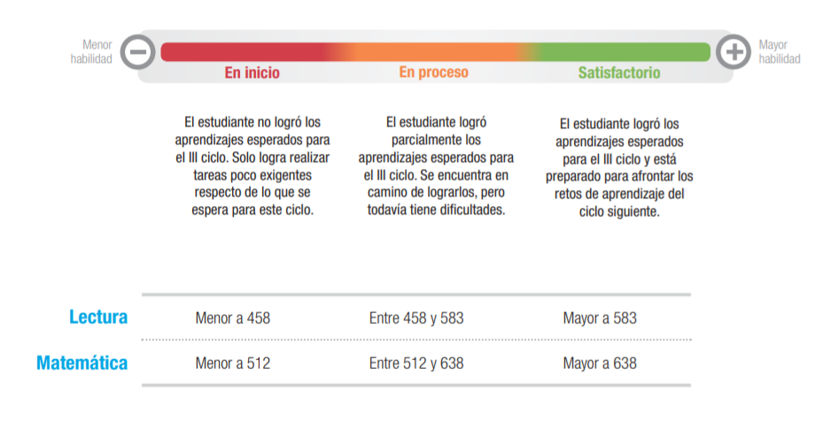

## 2.2 **Población, muestra y muestreo:**

Población : Todos los estudiantes que rindieron la evaluación Censal de Estudiantes en el año 2016 y 2015.

Muestra : La muestra corresponde a los estudiantes de segundo grado de primaria y su tamaño es de 571 224 estudiantes de todo el Perú.

Muestreo : En este caso se utilizó un muestreo estratificado, ya que la muestra corresponde a los resultados obtenidos por los estudiantes de segundo grado de primaria

## 2.3 **Variables**

```
      Variables
```

```
   Tipo
```

CODGEO

Categórica - nominal

REGION

Categórica - nominal

PROVINCIA

Categórica - nominal

DISTRITO

Categórica - nominal

Cobertura ie

Numérica - continua

Cobertura estudiantes

Numérica - continua

Medida promedio en Lectura

Númerica - continua

Medida promedio en Matemática

Númerica - continua

M_Region

Categórica - nominal

## 2.4 **Análisis descriptivo**

### 2.4.3 **Evolución de la cobertura de estudiantes entre los años 2015 y 2016**

| Descriptores Numéricos | 2015 | 2016 |
| --- | --- | --- |
| Media | 95.65 | 96.75 |
| Mediana | 96.4 | 97.6 |
| Rango | 20 | 20 |
| Varianza | 16.41 | 12.56 |
| Desviación Estándar | 4.05 | 3.54 |
| Rango Intercuartil | 5.45 | 4.9 |
| Coeficiente de Variación | 0.04 | 0.04 |

## 2.5 **Análisis probabilístico**

### 2.5.1 **Variable: Medida Promedio en Lectura de los años 2015 y 2016**

#### 2.5.1.1 **Comparamos la probabilidad de los estudiantes en satisfactorio Lectura en los años 2015 y 2016**

```
2015
```

```
 2016
```

```
0.38
```

```
 0.31
```

### 2.5.2 **Variable: Medida Promedio en Matemática de los años 2015 y 2016**

#### 2.5.2.1 **Comparamos la probabilidad de los estudiantes en satisfactorio Matemática en los años 2015 y 2016**

```
2015
```

```
 2016
```

```
0.13
```

```
 0.22
```